# Pairs Trading Assignment - Testing Cointegration

Selection criteria hypothesis: companies that are selling products which can be differentiated by marketing or other method are less likely to be mean reverting that companies that sell commodities (i.e. undifferentiable products). Using finviz.com’s stock screener, I selected the top companies by market cap in the “Farm Products” industry (greater than $1B market cap).

ADM - Archer-Daniels-Midland Company BG - Bunge Limited FDP - Fresh Del Monte Product Inc. IBA - Indusrias Bachoco, SAB de CV ANDE - The Andersons, Inc. CVGW - Calavo Growers, Inc.

```r
library(quantmod)
library(tseries)
library(dplyr)
library(tidyr)
start <- as.Date("2010-01-01")
end <- as.Date("2017-03-01")
farm.product.symbols <- c("ADM", "BG", "FDP", "IBA", "ANDE", "CVGW")
```

```r
getSymbols(farm.product.symbols, src = "yahoo", from = start, to = end)
```

```
pausing 1 second between requests for more than 5 symbols
pausing 1 second between requests for more than 5 symbols
```

```
[1] "ADM"  "BG"   "FDP"  "IBA"  "ANDE" "CVGW"
```

```r
# code cite: http://www.vikparuchuri.com/blog/time-series-cointegration-in-r/
# for background on why this function tests for cointegration via the Dicky-Fuller test, see:
# http://quantdevel.com/public/testForCoint.html
cointegration<-function(x,y){
  vals <- data.frame(x,y)
  beta <- coef(lm(vals[,2] ~ vals[,1] + 0, data = vals))[1]
  (adf.test(vals[,2] - beta*vals[,1], alternative = "stationary", k = 0))$p.value
}
cointegration(ADM$ADM.Close, BG$BG.Close)
```

```
[1] 0.1671961
```

Here, I create a matrix of closing prices.

```r
closing.prices <- cbind(ADM$ADM.Close, BG$BG.Close, FDP$FDP.Close, IBA$IBA.Close, ANDE$ANDE.Close)
```

```r
cointegration(closing.prices[,3], closing.prices[,2])
```

```
[1] 0.7883007
```

```r
cols <- ncol(closing.prices)
coint.pvalue <- NULL
for(i in 1:cols){
  for(j in 1:cols){
    coint.iter <- cointegration(closing.prices[,i], closing.prices[,j])
    coint.pvalue <- c(coint.pvalue, coint.iter)
  }
}
```

```
p-value smaller than printed p-valuep-value smaller than printed p-valuep-value smaller than printed p-value
```

```r
coint.pvalue.matrix <- matrix(coint.pvalue, ncol = cols, nrow = cols)
print(coint.pvalue.matrix)
```

```
           [,1]      [,2]      [,3]       [,4]      [,5]
[1,] 0.01000000 0.1681164 0.8550526 0.02355463 0.3432820
[2,] 0.16719607 0.0100000 0.7883007 0.25831073 0.2327450
[3,] 0.86161899 0.7977985 0.0174592 0.93431987 0.7177238
[4,] 0.02697652 0.2796325 0.9329585 0.01000000 0.3075918
[5,] 0.35484617 0.2476044 0.6902897 0.32063184 0.0456842
```

From this, it appears that ADM and IBA are cointegrated at a 95% p value. Ploting the two price series indicates that this is a reasonable conclusion.

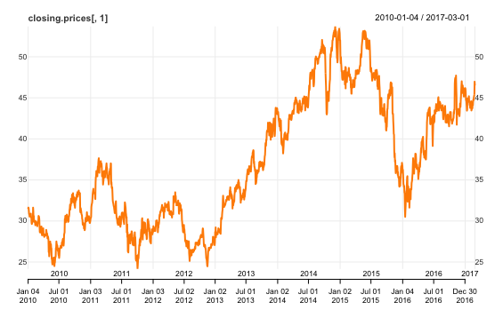

```r
chart_Series(closing.prices[,1])
```

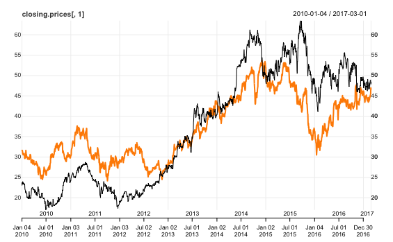

```r
add_TA(closing.prices[,4], on = 1)
```

```r
cor(closing.prices[,1], closing.prices[,4])
```

```
          IBA.Close
ADM.Close 0.8986189
```

One thing I wanted to check was the impact of country of origin. IBA is listed on the NY Stock Exchange, but is a Mexican company. Perhaps this has to do with the USD/MXN exchange rate.

```r
#the data source is limited to five years
getFX('USD/MXN', from = "2012-04-01", to = end)
```

```
[1] "USDMXN"
```

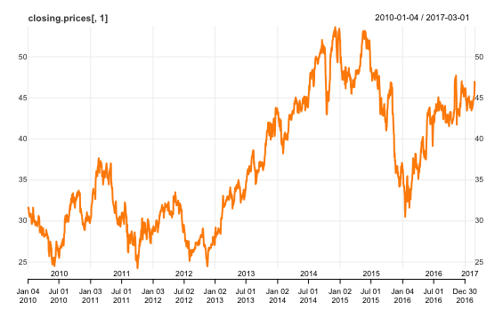

```r
chart_Series(closing.prices[,1])
```

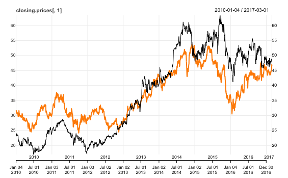

```r
add_TA(closing.prices[,4], on = 1)
```

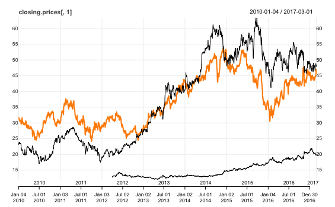

```r
add_TA(USDMXN, on = 1)
```

Perhaps adjusting for the currency exchange rate will reveal a different cointegration relationship.

```r
coint.adj <- merge.xts(USDMXN, closing.prices[,c(1,4)], join = 'inner')
coint.adj$USD.MXN <- coint.adj$USD.MXN / coint.adj$USD.MXN[[1]]
coint.adj$IBA.Close <- coint.adj$IBA.Close / coint.adj$USD.MXN
```

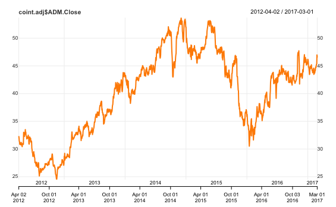

```r
chart_Series(coint.adj$ADM.Close)
```

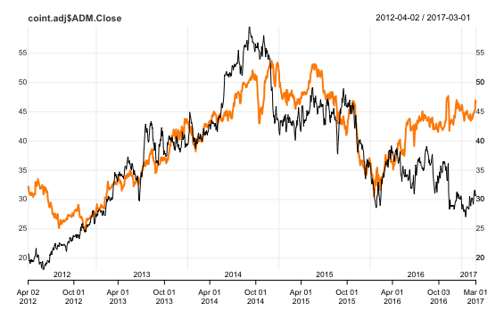

```r
add_TA(coint.adj$IBA.Close, on = 1)
```

```r
cointegration(coint.adj$ADM.Close, coint.adj$IBA.Close)
```

```
[1] 0.3893688
```

This adjustment for exchange rate means the stocks are no longer cointegrated, therefore the pairs trading should go ahead with just the unadjusted market price.